# Ch03 Publication Times

Bruce Hartman

University of St. Francis

2026-09-07 Revised 2026-10-15T09:56:47

Abstract

We study publication times in journals with data from `ISLR2`.

# Introduction

We are going to look at data about publication times for articles funded by the National Heart, Lung, and Blood Institute. The data are from the `ISLR2` package, but are not used in the text.

# Packages

Loading the standard packages for this course:

```r
library(ISLR2) # package contains the data files
library(mbadtools, quietly=TRUE) # for mbad courses
```

# Data

We get the data from the package. The data are from Gordon et al., 2013.

```r
data(Publication)
?Publication
Publication
```

| posres | multi | clinend | mech | sampsize | budget | impact | time | status |
| --- | --- | --- | --- | --- | --- | --- | --- | --- |
| 0 | 0 | 1 | R01 | 39876 | 8.016941 | 44.016 | 11.2032854 | 1 |
| 0 | 0 | 1 | R01 | 39876 | 8.016941 | 23.494 | 15.1786448 | 1 |
| 0 | 0 | 1 | R01 | 8171 | 7.612606 | 8.391 | 24.4106776 | 1 |
| 0 | 0 | 1 | Contract | 24335 | 11.771928 | 15.402 | 2.5954825 | 1 |
| 0 | 0 | 1 | Contract | 33357 | 76.517537 | 16.783 | 8.6078029 | 1 |
| 0 | 0 | 1 | Contract | 10355 | 9.809938 | 16.783 | 8.6078029 | 1 |
| 0 | 1 | 0 | U01 | 1704 | 23.818344 | 5.692 | 40.0492813 | 1 |
| 1 | 0 | 0 | R01 | 150 | 2.703848 | 3.496 | 27.0718686 | 1 |
| 0 | 0 | 0 | R01 | 135 | 3.454153 | 9.835 | 36.0082136 | 1 |
| 0 | 1 | 0 | Contract | 423 | 11.154085 | 16.783 | 9.6262834 | 1 |

[output cut: 234 more lines]

# Data Description

An initial attempt at description uses `skim`.

```r
Publication %>% skim
```

```
── Data Summary ────────────────────────
                           Values
Name                       Piped data
Number of rows             244
Number of columns          9
_______________________
Column type frequency:
  character                1
  numeric                  8
________________________
Group variables            None
```

|  | skim_variable | n_missing | complete_rate | min | max | empty | n_unique | whitespace |
| --- | --- | --- | --- | --- | --- | --- | --- | --- |
| 1 | mech | 0 | 1 | 3 | 8 | 0 | 14 | 0 |

|  | skim_variable | n_missing | complete_rate | mean | sd | p0 | p25 | p50 | p75 | p100 | hist |
| --- | --- | --- | --- | --- | --- | --- | --- | --- | --- | --- | --- |
| 1 | posres | 0 | 1 | 0.4016393 | 0.4912374 | 0.0000000 | 0.000000 | 0.000000 | 1.000000 | 1.0000 | ▇▁▁▁▆ |
| 2 | multi | 0 | 1 | 0.1516393 | 0.3594082 | 0.0000000 | 0.000000 | 0.000000 | 0.000000 | 1.0000 | ▇▁▁▁▂ |
| 3 | clinend | 0 | 1 | 0.1844262 | 0.3886286 | 0.0000000 | 0.000000 | 0.000000 | 0.000000 | 1.0000 | ▇▁▁▁▂ |
| 4 | sampsize | 0 | 1 | 2000.5737705 | 6206.0575359 | 18.0000000 | 150.000000 | 300.000000 | 810.250000 | 48835.0000 | ▇▁▁▁▁ |
| 5 | budget | 0 | 1 | 8.2837498 | 29.5390541 | 0.2500000 | 1.705712 | 2.800321 | 4.907661 | 415.1000 | ▇▁▁▁▁ |
| 6 | impact | 0 | 1 | 11.3447992 | 16.2791104 | 0.0000000 | 0.000000 | 3.873000 | 14.961250 | 53.4060 | ▇▁▁▁▁ |
| 7 | time | 0 | 1 | 24.7184839 | 21.7253168 | 0.9856263 | 9.913758 | 19.170431 | 33.018480 | 130.9897 | ▇▃▁▁▁ |
| 8 | status | 0 | 1 | 0.6393443 | 0.4811778 | 0.0000000 | 0.000000 | 1.000000 | 1.000000 | 1.0000 | ▅▁▁▁▇ |

There are 244 rows and 9 columns. There is one character variable, with 14 different values, not a candidate for a factor.

A glimpse is always useful.

```r
Publication %>% glimpse
```

```
Rows: 244
Columns: 9
$ posres   <int> 0, 0, 0, 0, 0, 0, 0, 1, 0, 0, 0, 0, 0, 0, 0, 1, 1, 1, 0,…
$ multi    <int> 0, 0, 0, 0, 0, 0, 1, 0, 0, 1, 0, 1, 0, 0, 0, 0, 0, 1, 0,…
$ clinend  <int> 1, 1, 1, 1, 1, 1, 0, 0, 0, 0, 1, 1, 1, 0, 0, 0, 1, 1, 1,…
$ mech     <chr> "R01", "R01", "R01", "Contract", "Contract", "Contract",…
$ sampsize <int> 39876, 39876, 8171, 24335, 33357, 10355, 1704, 150, 135,…
$ budget   <dbl> 8.016941, 8.016941, 7.612606, 11.771928, 76.517537, 9.80…
$ impact   <dbl> 44.016, 23.494, 8.391, 15.402, 16.783, 16.783, 5.692, 3.…
$ time     <dbl> 11.203285, 15.178645, 24.410678, 2.595483, 8.607803, 8.6…
$ status   <int> 1, 1, 1, 1, 1, 1, 1, 1, 1, 1, 1, 1, 1, 1, 1, 1, 1, 1, 1,…
```

> Publication {ISLR2} R Documentation

> Time-to-Publication Data

> Description Publication times for 244 clinical trials funded by the National Heart, Lung, and Blood Institute.

> Format A data frame with 244 observations, each representing a clinical trial, and 9 variables:

| Column | Description |
| --- | --- |
| posres | Did the trial produce a positive (significant) result? 1=Yes, 0=No. |
| multi | Did the trial involve multiple centers? 1=Yes, 0=No. |
| clinend | Did the trial focus on a clinical endpoint? 1=Yes, 0=No. |
| mech | Funding mechanism within National Institute of Health: a qualitative variable. |
| sampsize | Sample size for the trial. |
| budget | Budget of the trial, in millions of dollars. |
| impact | Impact of the trial; this is related to the number of publications. |
| time | Time to publication, in months. |
| status | Whether or not the trial was published at time: 1=Published, 0=Not yet published. |

# Data Wrangling

Four columns seem to be a 0-1 variable. Let’s make them factors. This is optional, but we don’t want regression to treat them as meaningful numeric values.

```r
Publication1 = Publication %>%
  mutate(across(c(posres, multi, clinend, status),
                factor) )
Publication1 %>% skim
```

```
── Data Summary ────────────────────────
                           Values
Name                       Piped data
Number of rows             244
Number of columns          9
_______________________
Column type frequency:
  character                1
  factor                   4
  numeric                  4
________________________
Group variables            None
```

|  | skim_variable | n_missing | complete_rate | min | max | empty | n_unique | whitespace |
| --- | --- | --- | --- | --- | --- | --- | --- | --- |
| 1 | mech | 0 | 1 | 3 | 8 | 0 | 14 | 0 |

|  | skim_variable | n_missing | complete_rate | ordered | n_unique | top_counts |
| --- | --- | --- | --- | --- | --- | --- |
| 1 | posres | 0 | 1 | FALSE | 2 | 0: 146, 1: 98 |
| 2 | multi | 0 | 1 | FALSE | 2 | 0: 207, 1: 37 |
| 3 | clinend | 0 | 1 | FALSE | 2 | 0: 199, 1: 45 |
| 4 | status | 0 | 1 | FALSE | 2 | 1: 156, 0: 88 |

|  | skim_variable | n_missing | complete_rate | mean | sd | p0 | p25 | p50 | p75 | p100 | hist |
| --- | --- | --- | --- | --- | --- | --- | --- | --- | --- | --- | --- |
| 1 | sampsize | 0 | 1 | 2000.57377 | 6206.05754 | 18.0000000 | 150.000000 | 300.000000 | 810.250000 | 48835.0000 | ▇▁▁▁▁ |
| 2 | budget | 0 | 1 | 8.28375 | 29.53905 | 0.2500000 | 1.705712 | 2.800321 | 4.907661 | 415.1000 | ▇▁▁▁▁ |
| 3 | impact | 0 | 1 | 11.34480 | 16.27911 | 0.0000000 | 0.000000 | 3.873000 | 14.961250 | 53.4060 | ▇▁▁▁▁ |
| 4 | time | 0 | 1 | 24.71848 | 21.72532 | 0.9856263 | 9.913758 | 19.170431 | 33.018480 | 130.9897 | ▇▃▁▁▁ |

This did the job.

# Data Visualization

A `ggpairs` plot of the numeric variables is a good idea.

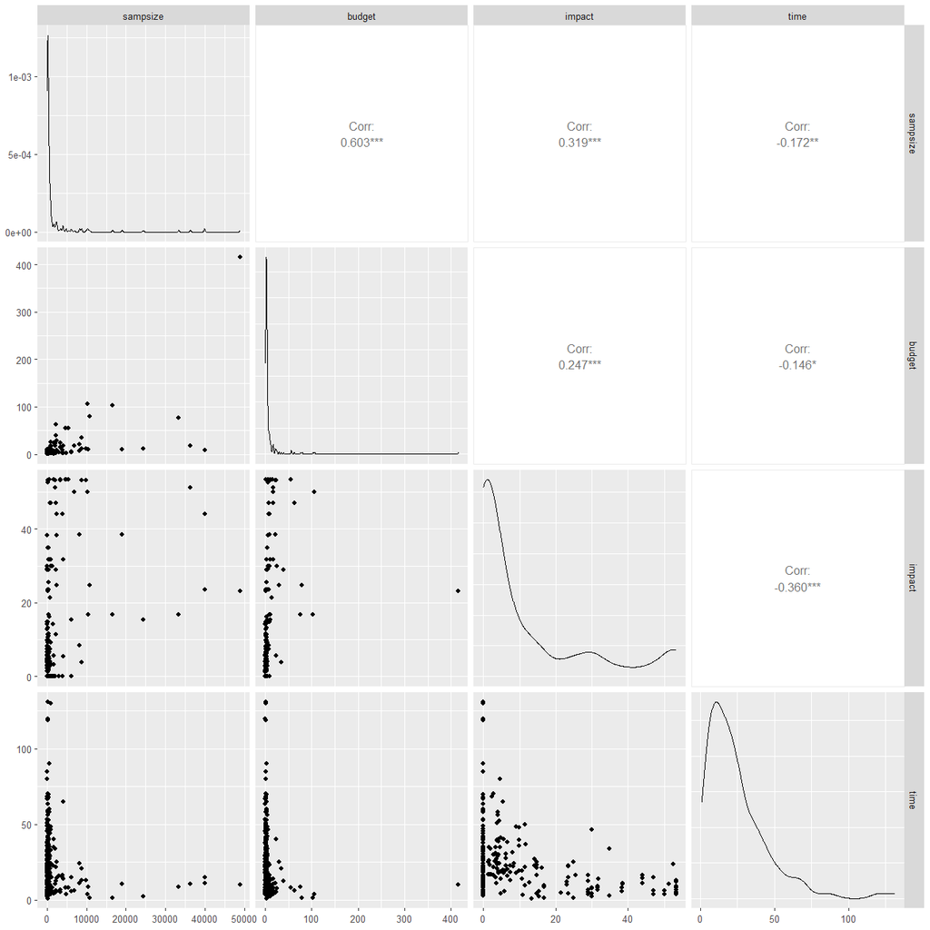

```r
Publication1 %>% select(where(is.numeric)) %>% ggpairs(progress=F)
```

Most papers were published fast, but there aren’t any other readily observable patterns.

# Research Problem

We will see whether `sampsize`, `budget` and `impact` have an influence on publication time. Perhaps a linear model applies.

# Analysis

We will try a linear model.

```r
linfit = lm(time ~ sampsize + budget + impact, data=Publication1)
linfit %>% glance %>% gt_add_significance()
```

| r.squared | adj.r.squared | sigma | statistic | p.value | df | logLik | AIC | BIC | deviance | df.residual | nobs |
| --- | --- | --- | --- | --- | --- | --- | --- | --- | --- | --- | --- |
| 0.1340 | 0.1232 | 20.3435 | 12.3777 | 0.0000 | 3.0000 | −1,079.3179 | 2,168.6357 | 2,186.1216 | 99,325.6213 | 240.0000 | 244.0000 |

```r
linfit %>% tidy(conf.int=TRUE) %>% gt_add_significance()
```

| term | estimate | std.error | statistic | p.value | conf.low | conf.high |
| --- | --- | --- | --- | --- | --- | --- |
| (Intercept) | 30.3450 | 1.5965 | 19.0067 | 0.0000 | 27.2000 | 33.4900 |
| sampsize | −0.0001 | 0.0003 | −0.5366 | 0.5921 | −0.0007 | 0.0004 |
| budget | −0.0282 | 0.0555 | −0.5074 | 0.6124 | −0.1376 | 0.0812 |
| impact | −0.4498 | 0.0848 | −5.3034 | 0.0000 | −0.6169 | −0.2827 |

The tidy shows us that `sampsize` and `budget` are not significant, their coefficients might well be zero. But `impact` has a negative relation to time. The adjusted R-squared is only .12, or 12% of the variation explained by this model. Not much.

## Residual analysis

We make some graphs of the residuals for analysis.

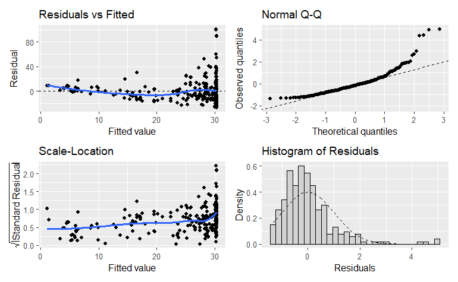

```r
linfit %>% gg_residual_plots()
```

There is an upward rise in the QQ plot, signifying that the residuals are not normally distributed. The Resid plot does show a mean of about 0, but there is significant variation in the larger fitted values compared to the smaller ones, a possible violation of assumptions. Finally in the LS plot there is rising variation with fitted values, not supporting the assumption of homoscedasticity.

We are not happy with this model.

# Including factors

We extend the analysis by adding `posres`,`multi`, and `clinend` factor variables. A positive result, more than one center, or a clinical end might influence the time to publication.

```r
linfit2 = lm(
  time ~ sampsize + budget + impact + posres + multi + clinend,
  data=Publication1)
linfit2 %>% glance %>% gt_add_significance()
```

| r.squared | adj.r.squared | sigma | statistic | p.value | df | logLik | AIC | BIC | deviance | df.residual | nobs |
| --- | --- | --- | --- | --- | --- | --- | --- | --- | --- | --- | --- |
| 0.1423 | 0.1206 | 20.3729 | 6.5557 | 0.0000 | 6.0000 | −1,078.1356 | 2,172.2712 | 2,200.2485 | 98,367.7267 | 237.0000 | 244.0000 |

```r
linfit2 %>% tidy(conf.int=TRUE) %>% gt_add_significance()
```

| term | estimate | std.error | statistic | p.value | conf.low | conf.high |
| --- | --- | --- | --- | --- | --- | --- |
| (Intercept) | 31.8067 | 2.0068 | 15.8497 | 0.0000 | 27.8534 | 35.7601 |
| sampsize | −0.0001 | 0.0003 | −0.2162 | 0.8290 | −0.0006 | 0.0005 |
| budget | −0.0294 | 0.0592 | −0.4959 | 0.6204 | −0.1461 | 0.0873 |
| impact | −0.3858 | 0.1163 | −3.3161 | 0.0011 | −0.6150 | −0.1566 |
| posres1 | −3.3893 | 2.7599 | −1.2280 | 0.2206 | −8.8265 | 2.0478 |
| multi1 | 0.3373 | 4.7930 | 0.0704 | 0.9439 | −9.1049 | 9.7796 |
| clinend1 | −5.5866 | 5.0566 | −1.1048 | 0.2704 | −15.5482 | 4.3749 |

The `glance` shows that the adjusted r-squared did not go up. The `tidy` shows that none of the new variables have coefficients significantly different from zero. In fact, again only `impact` is significant.

## Residuals 2

I do not think this will be better.

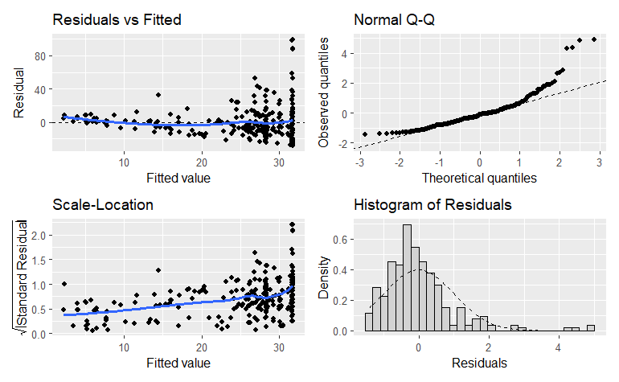

```r
linfit2 %>% gg_residual_plots()
```

And indeed it is not.

# Baseline with impact only

We will analyze the regression with only `impact` before looking at other models.

```r
linfit1 = lm(time ~ impact, data=Publication1)
linfit1 %>% glance %>% gt_add_significance()
```

| r.squared | adj.r.squared | sigma | statistic | p.value | df | logLik | AIC | BIC | deviance | df.residual | nobs |
| --- | --- | --- | --- | --- | --- | --- | --- | --- | --- | --- | --- |
| 0.1294 | 0.1258 | 20.3128 | 35.9700 | 0.0000 | 1.0000 | −1,079.9624 | 2,165.9249 | 2,176.4164 | 99,851.8013 | 242.0000 | 244.0000 |

```r
linfit1 %>% tidy(conf.int=TRUE) %>% gt_add_significance()
```

| term | estimate | std.error | statistic | p.value | conf.low | conf.high |
| --- | --- | --- | --- | --- | --- | --- |
| (Intercept) | 30.1648 | 1.5861 | 19.0184 | 0.0000 | 27.0405 | 33.2891 |
| impact | −0.4801 | 0.0800 | −5.9975 | 0.0000 | −0.6377 | −0.3224 |

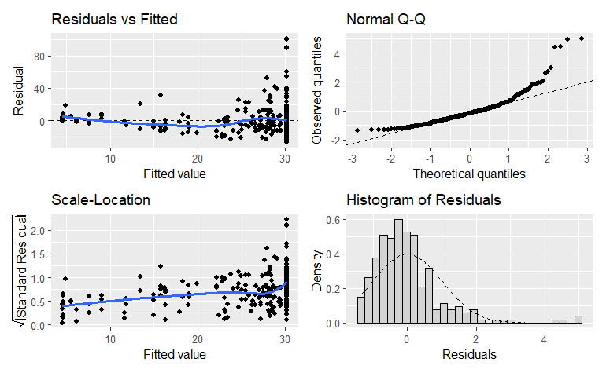

```r
linfit1 %>% gg_residual_plots()
```

No worse and no better.

Occam’s Razor tells us that the last regression model, `linfit1`, is best so far, being easier to explain.

# Does status matter?

Maybe the status of the article makes a difference in the time, as well as the impact.

```r
linfits = lm(time ~ impact + status, data=Publication1)
linfits %>% glance %>% gt_add_significance()
```

| r.squared | adj.r.squared | sigma | statistic | p.value | df | logLik | AIC | BIC | deviance | df.residual | nobs |
| --- | --- | --- | --- | --- | --- | --- | --- | --- | --- | --- | --- |
| 0.1294 | 0.1222 | 20.3549 | 17.9108 | 0.0000 | 2.0000 | −1,079.9624 | 2,167.9248 | 2,181.9135 | 99,851.7574 | 241.0000 | 244.0000 |

```r
linfits %>% tidy(conf.int=TRUE) %>% gt_add_significance()
```

| term | estimate | std.error | statistic | p.value | conf.low | conf.high |
| --- | --- | --- | --- | --- | --- | --- |
| (Intercept) | 30.1800 | 2.1698 | 13.9088 | 0.0000 | 25.9057 | 34.4543 |
| impact | −0.4796 | 0.0941 | −5.0943 | 0.0000 | −0.6650 | −0.2941 |
| status1 | −0.0328 | 3.1849 | −0.0103 | 0.9918 | −6.3065 | 6.2409 |

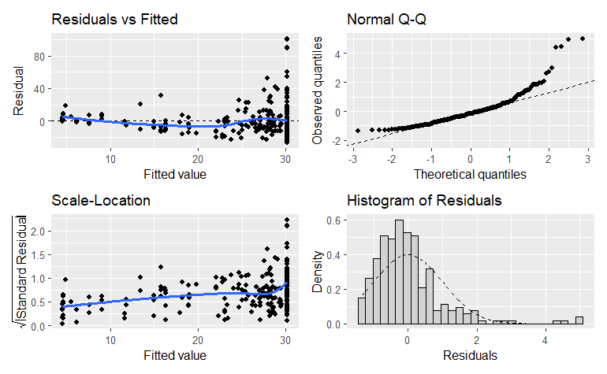

```r
linfits  %>% gg_residual_plots()
```

`status` does not seem to matter, as its coefficient might as well be zero.

# Funding Mechanism

There’s one more variable, `mech`, that we have not tried yet. It has 14 discrete values, which cannot be handled properly as a factor.

Let’s explore by looking at the distribution of data.

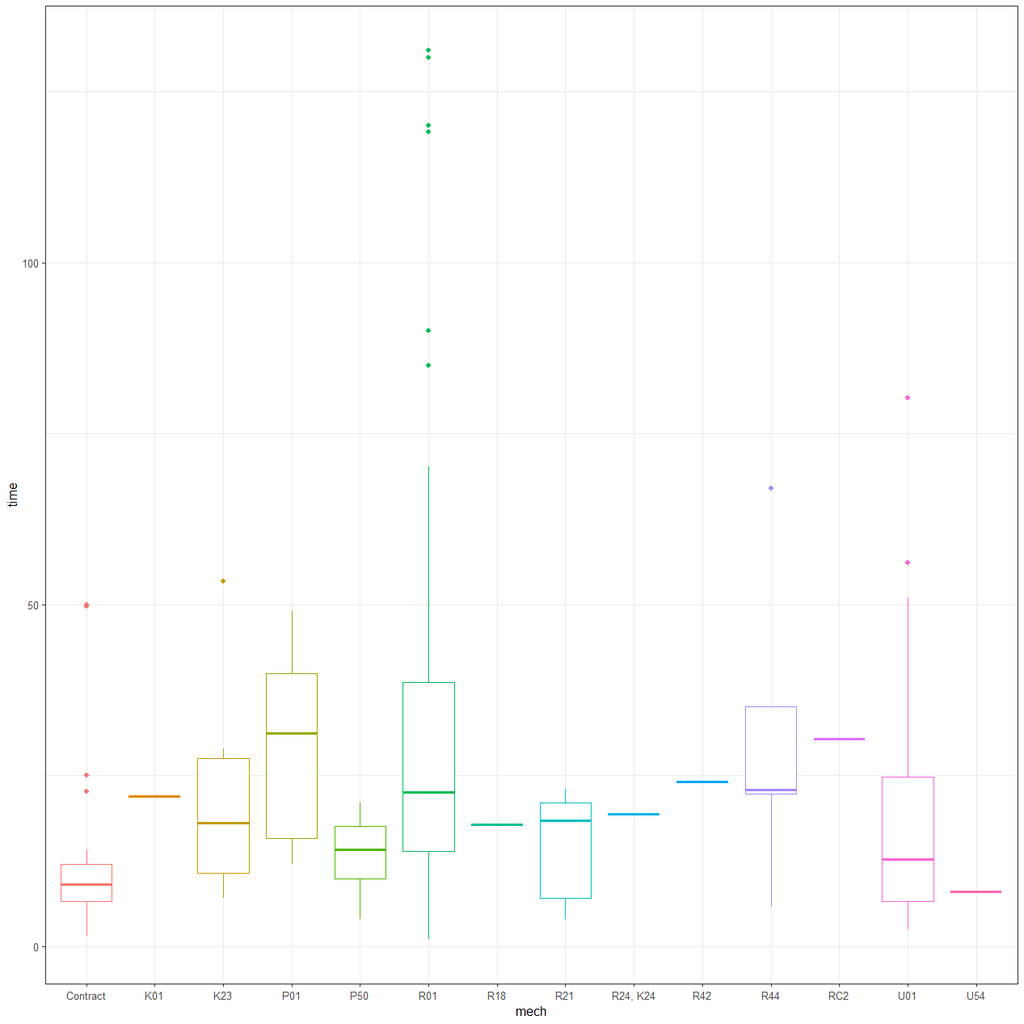

```r
Publication1 %>% ggplot() +
  geom_boxplot(aes(mech, time, color=mech), show.legend=F)+
  theme_bw()
```

# Impact and `posres`

You would think that a positive result and impact taken together would make a bigger difference than one or the other. This is called an interaction effect. That’s a conjecture, framed as a hypothesis. Let’s test it.

```r
linfiti = lm(time ~ impact*posres, data=Publication1)
linfiti %>% glance %>% gt_add_significance()
```

| r.squared | adj.r.squared | sigma | statistic | p.value | df | logLik | AIC | BIC | deviance | df.residual | nobs |
| --- | --- | --- | --- | --- | --- | --- | --- | --- | --- | --- | --- |
| 0.1321 | 0.1213 | 20.3652 | 12.1803 | 0.0000 | 3.0000 | −1,079.5789 | 2,169.1578 | 2,186.6436 | 99,538.3574 | 240.0000 | 244.0000 |

```r
linfiti %>% tidy(conf.int=TRUE) %>% gt_add_significance()
```

| term | estimate | std.error | statistic | p.value | conf.low | conf.high |
| --- | --- | --- | --- | --- | --- | --- |
| (Intercept) | 31.2148 | 2.0780 | 15.0219 | 0.0000 | 27.1214 | 35.3082 |
| impact | −0.4903 | 0.0968 | −5.0654 | 0.0000 | −0.6810 | −0.2996 |
| posres1 | −2.4458 | 3.2367 | −0.7556 | 0.4506 | −8.8216 | 3.9301 |
| impact:posres1 | 0.0126 | 0.1747 | 0.0723 | 0.9424 | −0.3316 | 0.3568 |

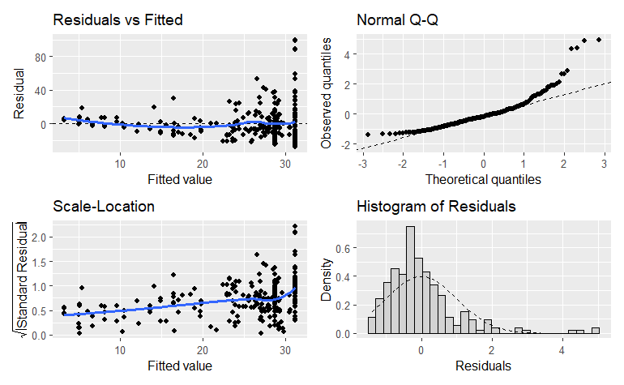

```r
linfiti %>% gg_residual_plots()
```

Neither `posres` nor the product of `posres` and `impact` makes any difference; both coefficients are not significantly different from zero. The r-squared doesn’t change.

Residuals behavior is not improved.

# Conclusion

My conclusions are that the simplest model with only `impact` as a driver is the best of a bad lot. None of them has much predictive value.

Perhaps publication times of results are not influenced much, if at all, by any of these drivers. It’s mostly random.

We also saw how to make a table in the text. Kind of funky, but doable.

# References

1. Hartman, B. (2026) Basic Notebook Template. (https://1drv.ms/u/c/50100c84fbd246fa/IQD6RtL7hAwQIIBQrSYIAAAAAUGMxvUirsrlRdX5fojUAaY?e=BemEMv)
2. James, G., Witten, D., Hastie, T., and Tibshirani, R. (2021) An Introduction to Statistical Learning with applications in R, Second Edition, (https://www.statlearning.com), Springer-Verlag, New York

3.Gordon, Taddei-Peters, Mascette, Antman, Kaufmann, and Lauer. Publication of trials funded by the National Heart, Lung, and Blood Institute. New England Journal of Medicine, 369(20):1926-1934, 2013.